# JHU_COVID19_Data

Adam McKeeby

10/3/2021

#### Pull down CSV files

```r
baseURI <- "https://raw.githubusercontent.com/CSSEGISandData/COVID-19/master/csse_covid_19_data/csse_covid_19_time_series/"
lookupURL <- "https://raw.githubusercontent.com/CSSEGISandData/COVID-19/master/csse_covid_19_data/UID_ISO_FIPS_LookUp_Table.csv"
csvFiles <- c(
    "time_series_covid19_confirmed_US.csv",
    "time_series_covid19_deaths_US.csv",
    "time_series_covid19_confirmed_global.csv",
    "time_series_covid19_deaths_global.csv"
)

urlVec <- str_c(baseURI, csvFiles)
```

#### Store CSV data in memory

```r
usCases <- read_csv(urlVec[1], show_col_types = FALSE)
usDeaths <- read_csv(urlVec[2], show_col_types = FALSE)
globalCases <- read_csv(urlVec[3], show_col_types = FALSE)
globalDeaths <- read_csv(urlVec[4], show_col_types = FALSE)
uidLookup <- read_csv(lookupURL, show_col_types = FALSE)
```

#### Data Description

Data currently contains: - Province/State  
- Country/Region  
- Lat  
- Long

#### Tidy data and add desired columns

```r
# Pivot dates, format dates, add month and year columns, join with UID data, drop NA rows, add cases/1000 column
tidyGC <- globalCases %>%
    drop_na(Lat) %>%
    rename(Country_Region = `Country/Region`) %>%
    pivot_longer( cols = -c(`Province/State`, Country_Region, Lat, Long),
                  names_to = "date",
                  values_to = "cases"
    ) %>%
    mutate(date = mdy(date)) %>%
    mutate(month = month(date)) %>%
    mutate(year = year(date)) %>%
    left_join(uidLookup, by = c("Country_Region", "Lat")) %>%
    select(-c(UID, FIPS)) %>%
    select(Country_Region, Lat, date, month, year, cases, Population) %>%
    drop_na() %>%
    mutate(cases_per_thou = 1000 * cases / Population)

# Pivot dates, format dates, add month and year columns, join with UID data, drop NA rows, add cases/1000 column
tidyGD <- globalDeaths %>%
    drop_na(Lat) %>%
    rename(Country_Region = `Country/Region`) %>%
    pivot_longer( cols = -c(`Province/State`, Country_Region, Lat, Long),
                  names_to = "date",
                  values_to = "cases"
    ) %>%
    mutate(date = mdy(date)) %>%
    mutate(month = month(date)) %>%
    mutate(year = year(date)) %>%
    left_join(uidLookup, by = c("Country_Region", "Lat")) %>%
    select(-c(UID, FIPS)) %>%
    select(Country_Region, Lat, date, month, year, cases, Population) %>%
    drop_na() %>%
    mutate(deaths_per_thou = 1000 * cases / Population)
```

#### Separate data into regional buckets

```r
# setup latitude region bounds
tropicOfCancer <- 23.436720
tropicOfCapricorn <- -23.436720
subNTropic <- 35.0
subSTropic <- -35.0
northTemperate <- 66.50
southTemperate <- -66.50

# separate each row into Tropics/SubTropics/Temperate/Polar regions for global cases
tidyGC["region"] <- case_when(
    (tidyGC["Lat"] > tropicOfCapricorn) & (tidyGC["Lat"] < tropicOfCancer) ~ "Tropics",
    (tidyGC["Lat"] > tropicOfCancer) & (tidyGC["Lat"] < subNTropic) ~ "SubTropics",
    (tidyGC["Lat"] > subSTropic) & (tidyGC["Lat"] < tropicOfCapricorn) ~ "SubTropics",
    (tidyGC["Lat"] > subNTropic) & (tidyGC["Lat"] < northTemperate ) ~ "Temperate",
    (tidyGC["Lat"] > southTemperate ) & (tidyGC["Lat"] < subSTropic) ~ "Temperate",
    (tidyGC["Lat"] > northTemperate) ~ "Polar",
    (tidyGC["Lat"] < southTemperate)  ~ "Polar",
)

# separate each row into Tropics/SubTropics/Temperate/Polar regions for global deaths
tidyGD["region"] <- case_when(
    (tidyGC["Lat"] > tropicOfCapricorn) & (tidyGC["Lat"] < tropicOfCancer) ~ "Tropics",
    (tidyGC["Lat"] > tropicOfCancer) & (tidyGC["Lat"] < subNTropic) ~ "SubTropics",
    (tidyGC["Lat"] > subSTropic) & (tidyGC["Lat"] < tropicOfCapricorn) ~ "SubTropics",
    (tidyGC["Lat"] > subNTropic) & (tidyGC["Lat"] < northTemperate ) ~ "Temperate",
    (tidyGC["Lat"] > southTemperate ) & (tidyGC["Lat"] < subSTropic) ~ "Temperate",
    (tidyGC["Lat"] > northTemperate) ~ "Polar",
    (tidyGC["Lat"] < southTemperate)  ~ "Polar",
)

# filter out rows with 0 population and 0 cases
gcSummary <- tidyGC %>%
    group_by(region) %>%
    summarize(cases = max(cases),
              population = max(Population),
              cases_per_thou = 1000 * cases / population
    ) %>%
    filter(cases > 0, population > 0)

gdSummary <- tidyGD %>%
    group_by(region) %>%
    summarize(deaths = max(cases),
              population = max(Population),
              deaths_per_thou = 1000 * deaths / population
    ) %>%
    filter(deaths > 0, population > 0)
```

#### Create Models for each region

```r
# Create grouped data sets and matching models for global cases

temperateGC <- tidyGC %>%
    filter(region == "Temperate") %>%
    group_by(date) %>%
    summarise(
        mean_cpt = mean(cases_per_thou),
        cases_per_thou = sum(cases_per_thou),
        n = n(),
        region = "Temperate"
    )
tempModel <- glm(mean_cpt ~ cases_per_thou / date, data = temperateGC)
temperateGC <- temperateGC %>% mutate(prediction = predict(tempModel))

polarGC <- tidyGC %>%
    filter(region == "Polar") %>%
    group_by(date) %>%
    summarise(
        mean_cpt = mean(cases_per_thou),
        cases_per_thou = sum(cases_per_thou),
        n = n(),
        region = "Polar"
    )
polModel <- glm(mean_cpt ~ cases_per_thou / date, data = polarGC)
polarGC <- polarGC %>% mutate(prediction = predict(polModel))

tropGC <- tidyGC %>%
    filter(region == "Tropics") %>%
    group_by(date) %>%
    summarise(
        mean_cpt = mean(cases_per_thou),
        cases_per_thou = sum(cases_per_thou),
        n = n(),
        region = "Tropics"
    )
tropModel <- glm(mean_cpt ~ cases_per_thou / date, data = tropGC)
tropGC <- tropGC %>% mutate(prediction = predict(tropModel))


subGC <- tidyGC %>%
    filter(region == "SubTropics") %>%
    group_by(date) %>%
    summarise(
        mean_cpt = mean(cases_per_thou),
        cases_per_thou = sum(cases_per_thou),
        n = n(),
        region = "SubTropics"
    )
subModel <- glm(mean_cpt ~ cases_per_thou / date, data = subGC)
subGC <- subGC %>% mutate(prediction = predict(subModel))
```

### Research Questions/ Questions of Interest:

Does climate affect the spread and how deadly COVID is in humans?  
Specifically does COVID spread less effectively the warmer the climate?

### Hypothesis:

As COVID spreads closer to the equator, it will be less effective at spreading and causing death.

### Analyses

For the sake of binning for analysis, the latitude regions will be defined as:  
- Tropics: Between Tropic Of Cancer(23.436720) and Tropic Of Capricorn(-23.436720)  
- SubTropics: Between Tropic of Cancer and latitude 35.0 degrees. Between Tropic of Capricorn and latitude -35.0 degrees  
- Temperate: Latitudes 35.0 to 66.50 degrees and -35.0 to -66.50 degrees - Polar: Latitude 66.5 degrees and up. Latitude -66.5 degrees and below

NOTE: Linears models are in red on the graphs

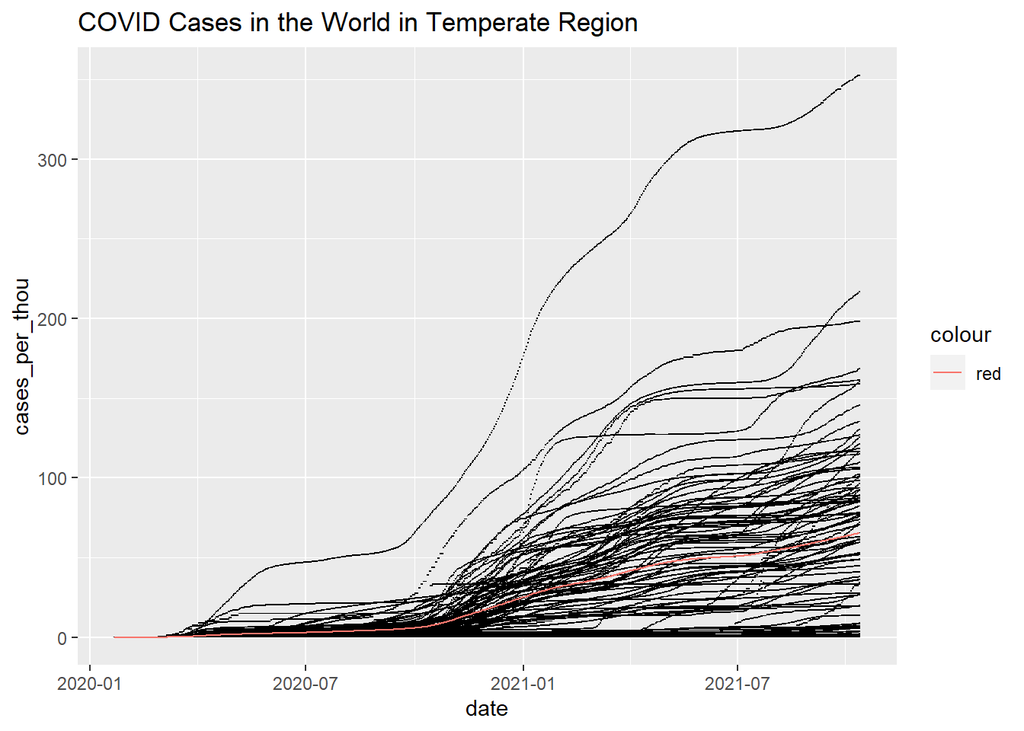

```r
ggplot(data = tidyGC %>% filter(region == "Temperate")) +
geom_point( aes(x=date, y=cases_per_thou ), shape = ".") +
geom_line(data = temperateGC, aes(x=date, y=prediction, color = "red")) +
labs(title = "COVID Cases in the World in Temperate Region")
```

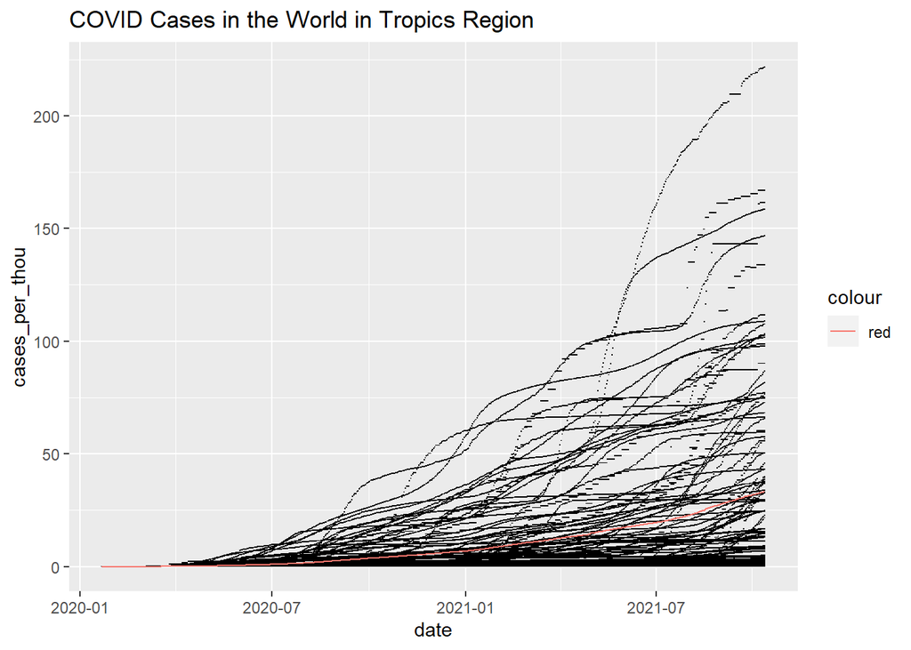

```r
ggplot(data = tidyGC %>% filter(region == "Tropics")) +
geom_point( aes(x=date, y=cases_per_thou ), shape = ".") +
geom_line(data = tropGC, aes(x=date, y=prediction, color = "red")) +
labs(title = "COVID Cases in the World in Tropics Region")
```

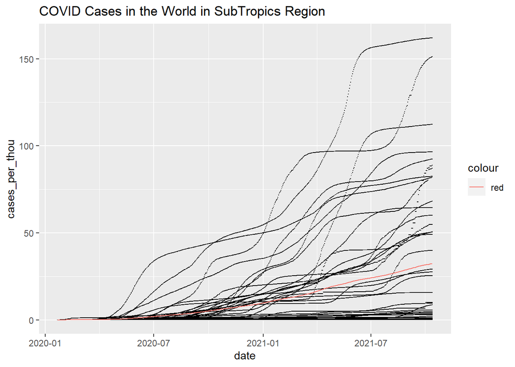

```r
ggplot(data = tidyGC %>% filter(region == "SubTropics")) +
geom_point( aes(x=date, y=cases_per_thou ), shape = ".") +
geom_line(data = subGC, aes(x=date, y=prediction, color = "red")) +
labs(title = "COVID Cases in the World in SubTropics Region")
```

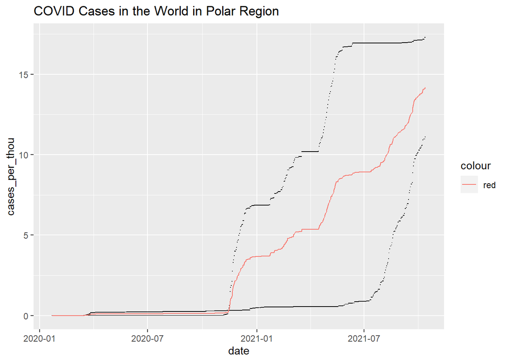

```r
ggplot(data = tidyGC %>% filter(region == "Polar")) +
geom_point( aes(x=date, y=cases_per_thou), shape = ".") +
geom_line(data = polarGC, aes(x=date, y=prediction, color = "red")) +
labs(title = "COVID Cases in the World in Polar Region")
```

### Analysis of COVID Cases throughout the world based on Latitude Region

- The main density of countries in the temperate region tended to have higher cases per thousand than polar, tropics and subtropics.
- Countries in the polar region had a very low sample size. Some of those countries were split across the polar/temperate border with a bulk of their population density in the temperate area (Canada is a good example of this happening )
- The Temperate region had the most countries in it’s group, followed by tropics, subtropics and polar.
- As the latitude regions moved south, the linear models predicted less cases per thousand with the exception of the polar region

```r
# Create grouped datasets and matching models for global deaths
temperateGD <- tidyGD %>%
    filter(region == "Temperate") %>%
    group_by(date) %>%
    summarise(
        mean_dpt = mean(deaths_per_thou),
        deaths_per_thou = sum(deaths_per_thou),
        n = n(),
        region = "Temperate"
    )
tempDModel <- glm(mean_dpt ~ deaths_per_thou / date, data = temperateGD)
temperateGD <- temperateGD %>% mutate(prediction = predict(tempDModel))

polarGD <- tidyGD %>%
    filter(region == "Polar") %>%
    group_by(date) %>%
    summarise(
        mean_dpt = mean(deaths_per_thou),
        deaths_per_thou = sum(deaths_per_thou),
        n = n(),
        region = "Polar"
    )
polDModel <- glm(mean_dpt ~ deaths_per_thou / date, data = polarGD)
polarGD <- polarGD %>% mutate(prediction = predict(polDModel))

tropGD <- tidyGD %>%
    filter(region == "Tropics") %>%
    group_by(date) %>%
    summarise(
        mean_dpt = mean(deaths_per_thou),
        deaths_per_thou = sum(deaths_per_thou),
        n = n(),
        region = "Tropics"
    )
tropDModel <- glm(mean_dpt ~ deaths_per_thou / date, data = tropGD)
tropGD <- tropGD %>% mutate(prediction = predict(tropDModel))


subGD <- tidyGD %>%
    filter(region == "SubTropics") %>%
    group_by(date) %>%
    summarise(
        mean_dpt = mean(deaths_per_thou),
        deaths_per_thou = sum(deaths_per_thou),
        n = n(),
        region = "SubTropics"
    )
subDModel <- glm(mean_dpt ~ deaths_per_thou / date, data = subGD)
subGD <- subGD %>% mutate(prediction = predict(subDModel))
```

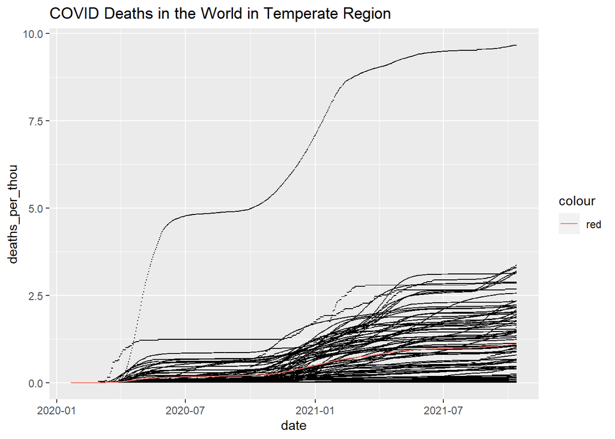

```r
ggplot(data = tidyGD %>% filter(region == "Temperate")) +
geom_point( aes(x=date, y=deaths_per_thou ), shape = ".") +
geom_line(data = temperateGD, aes(x=date, y=prediction, color = "red")) +
labs(title = "COVID Deaths in the World in Temperate Region")
```

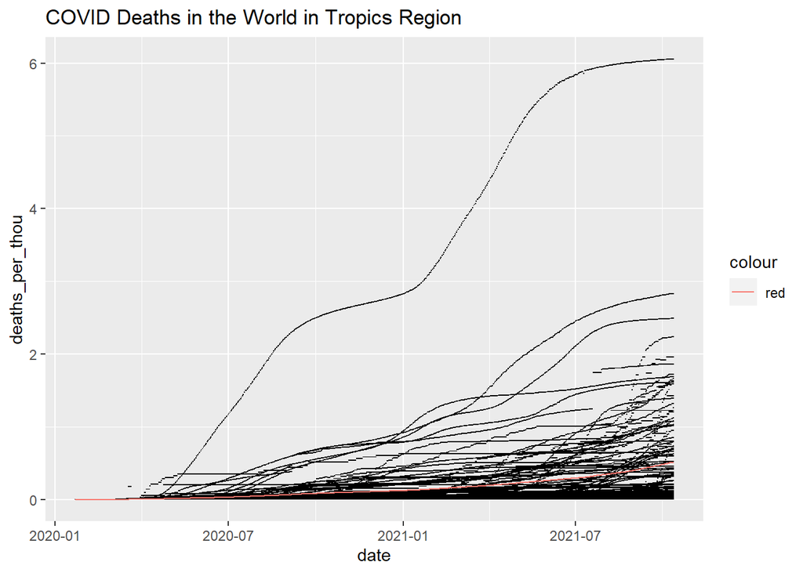

```r
ggplot(data = tidyGD %>% filter(region == "Tropics")) +
geom_point( aes(x=date, y=deaths_per_thou ), shape = ".") +
geom_line(data = tropGD, aes(x=date, y=prediction, color = "red")) +
labs(title = "COVID Deaths in the World in Tropics Region")
```

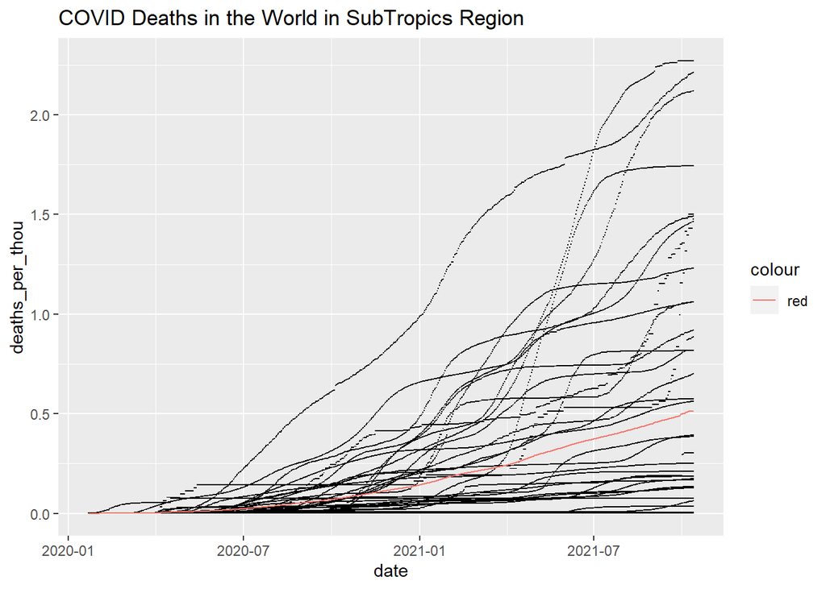

```r
ggplot(data = tidyGD %>% filter(region == "SubTropics")) +
geom_point( aes(x=date, y=deaths_per_thou ), shape = ".") +
geom_line(data = subGD, aes(x=date, y=prediction, color = "red")) +
labs(title = "COVID Deaths in the World in SubTropics Region")
```

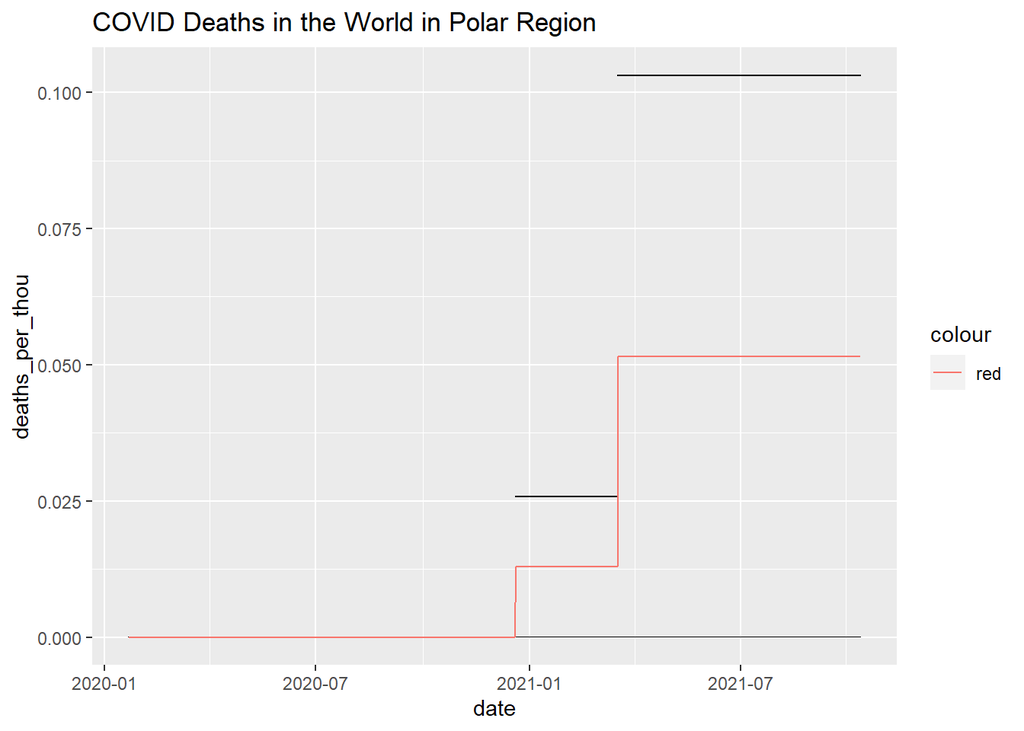

```r
ggplot(data = tidyGD %>% filter(region == "Polar")) +
geom_point( aes(x=date, y=deaths_per_thou ), shape = ".") +
geom_line(data = polarGD, aes(x=date, y=prediction, color = "red")) +
labs(title = "COVID Deaths in the World in Polar Region")
```

### Conclusion

Based on this data and analysis, it appears that as we move closer to the equator, COVID spread and deaths decrease on average with the exception of the polar region. So the hypothesis is only partially upheld.

There are a few problems with bias and the analysis though. For example, I think that since the “polar” region only consists of two countries( Denmark and Canada ), those graphs and analysis are probably oversampled. Canada specifically poses a problem because it was split between the temperate and polar regions, with the bulk of its population in the temperate region. Also, this sort of analysis and (arguably mismatched) dataset is not ideal for the research question question. First, climate is not so simple that it can just be binned efficiently within just latitude bans on the Earth. At best, it only provides very general trends of warm and wet climates as you move closer to the equator. Secondly, the epidemiological behaviors of COVID spread is difficult to confine to just one dimension. There are many factors at play, such as how cultures, health care policy, health care infrastructure, country affluency, weather patterns(especially those that differ between northern and southern hemispheres like La Nina/El Nino), when a country/population was exposed, governments, etc have responded to the spread of COVID that can drastically affect the results, and therefore analysis.

All of the factors I just listed can introduce major bias in how the results are interpreted and reported. For example, with regards to the United States culture and government, there are communities and organizations that at different times refuse(d) the existence of COVID or refused to change health care policy, receive vaccines, etc which all can adversely affect reporting/sampling of the data and change the results for the United States specifically. Multiply all that variability by all the different countries and their types of governments and cultures, and that alone causes these analyses to become significantly more complex, nuanced and flawed.  
So it is important to contextualize these data and analyses, that although the general trends seem to be that climate and weather do seem to have an impact it is an incomplete picture.